# **Tarea Diplomado**

#### Autor: Jorge Carrasco

#### Profesores: José Gallardo - María Angelica Rueda

### **Descripción del problema**

##### Analizar la base de datos de origen publico, La cual especifica la cantidad de kilos de distintas especies de recursos extraibles del mar, la idea es poder lograr pronosticar en una serie de tiempo la cantidad de kilos maximos a extrar por mes de cada recurso, con el fin de poder planificar de mejor manera la logistica y el area comercial para el negocio.

##### **Estos datos provienen del siguiente URL:**

[Link de la base de datos](https://datos.gob.cl/dataset/desembarque-artesanal-2019-preliminar)

```r
dataset <- read_xlsx("Desembarque por caleta y recurso.xlsx")
```

#### Realizamos la primera exploración de datos:

```r
head(dataset)
```

| Region | Provincia | Comuna | Caleta | Especie | ENE | FEB | MAR | ABR | MAY | JUN | JUL | AGO | SEP | OCT | NOV | DIC | Total |
| --- | --- | --- | --- | --- | --- | --- | --- | --- | --- | --- | --- | --- | --- | --- | --- | --- | --- |
| 1 | Iquique | Iquique | CAÑAMO | ACHA O HACHA | 0 | 0 | 35 | 0 | 0 | 28 | 0 | 21 | 0 | 0 | 0 | 0 | 84 |
| 1 | Iquique | Iquique | CAÑAMO | ALMEJA | 9 | 18 | 63 | 115 | 646 | 108 | 5 | 29 | 23 | 85 | 85 | 9 | 1195 |
| 1 | Iquique | Iquique | CAÑAMO | APAÑADO | 0 | 0 | 0 | 0 | 0 | 0 | 0 | 0 | 0 | 0 | 5 | 0 | 5 |
| 1 | Iquique | Iquique | CAÑAMO | CABRILLA ESPAÑOLA | 0 | 0 | 0 | 0 | 0 | 0 | 0 | 0 | 0 | 0 | 15 | 0 | 15 |
| 1 | Iquique | Iquique | CAÑAMO | CONGRIO NEGRO | 0 | 0 | 7 | 0 | 0 | 0 | 0 | 0 | 0 | 0 | 0 | 0 | 7 |
| 1 | Iquique | Iquique | CAÑAMO | ERIZO | 56 | 0 | 5 | 99 | 66 | 109 | 0 | 0 | 12 | 2423 | 0 | 0 | 2770 |

#### Usamos la función gather, para unificar los meses y los kilos en una sola columna, ademas eliminamos la columna Total.(creamos un nuevo dataset)

```r
dataset2 <- gather(data = dataset, key = "Meses", value = "Kilos", 6:17)
dataset2 <- select(dataset2, -Total) #Eliminamos el total


# Definir la función para eliminar puntos y separadores de miles
eliminar_puntos <- function(numero_decimal) {
  numero_entero <- as.integer(gsub("\\D", "", numero_decimal))
  return(numero_entero)
}

# Aplicar la función a la variable "Kilos" de la base de datos "dataset"
dataset <- dataset2 %>%
  mutate(Kilos_enteros = eliminar_puntos(Kilos))

dataset2 <- dataset2 %>%
  mutate(Toneladas = Kilos / 1000)

head(dataset2)
```

| Region | Provincia | Comuna | Caleta | Especie | Meses | Kilos | Toneladas |
| --- | --- | --- | --- | --- | --- | --- | --- |
| 1 | Iquique | Iquique | CAÑAMO | ACHA O HACHA | ENE | 0 | 0.000 |
| 1 | Iquique | Iquique | CAÑAMO | ALMEJA | ENE | 9 | 0.009 |
| 1 | Iquique | Iquique | CAÑAMO | APAÑADO | ENE | 0 | 0.000 |
| 1 | Iquique | Iquique | CAÑAMO | CABRILLA ESPAÑOLA | ENE | 0 | 0.000 |
| 1 | Iquique | Iquique | CAÑAMO | CONGRIO NEGRO | ENE | 0 | 0.000 |
| 1 | Iquique | Iquique | CAÑAMO | ERIZO | ENE | 56 | 0.056 |

#### A nuestra nueva base de datos realizamos un resumen.

```r
summary(dataset2)
```

```
##      Region       Provincia            Comuna             Caleta
##  Min.   : 1.00   Length:109740      Length:109740      Length:109740
##  1st Qu.: 4.00   Class :character   Class :character   Class :character
##  Median : 8.00   Mode  :character   Mode  :character   Mode  :character
##  Mean   : 7.56
##  3rd Qu.:10.00
##  Max.   :99.00
##    Especie             Meses               Kilos            Toneladas
##  Length:109740      Length:109740      Min.   :       0   Min.   :    0.000
##  Class :character   Class :character   1st Qu.:       0   1st Qu.:    0.000
##  Mode  :character   Mode  :character   Median :       0   Median :    0.000
##                                        Mean   :    8964   Mean   :    8.964
##                                        3rd Qu.:       9   3rd Qu.:    0.009
##                                        Max.   :27636887   Max.   :27636.887
```

```r
dataset3 <- dataset2 %>%
  mutate(Kilos = ifelse(is.na(Kilos), 0, Kilos))
summary(dataset3)
```

```
##      Region       Provincia            Comuna             Caleta
##  Min.   : 1.00   Length:109740      Length:109740      Length:109740
##  1st Qu.: 4.00   Class :character   Class :character   Class :character
##  Median : 8.00   Mode  :character   Mode  :character   Mode  :character
##  Mean   : 7.56
##  3rd Qu.:10.00
##  Max.   :99.00
##    Especie             Meses               Kilos            Toneladas
##  Length:109740      Length:109740      Min.   :       0   Min.   :    0.000
##  Class :character   Class :character   1st Qu.:       0   1st Qu.:    0.000
##  Mode  :character   Mode  :character   Median :       0   Median :    0.000
##                                        Mean   :    8964   Mean   :    8.964
##                                        3rd Qu.:       9   3rd Qu.:    0.009
##                                        Max.   :27636887   Max.   :27636.887
```

#### Otro proceso necesario es convertir nuestra variable “Kilos” a numerica

```r
dataset3$Kilos <- as.numeric(dataset3$Kilos)
class(dataset3$Kilos)
```

```
## [1] "numeric"
```

#### En la base de datos tambien tenemos otros valores atipicos por ejemplo: en la variable Region tenemos la Region 99, la cual no especifica “Provincia”, “Caleta” ni “Comuna”, Eliminamos las filas con la region 99 que no especificaban datos y creamos nuestro ultimo DF.

```r
subset_dataset <- dataset3 %>%
  filter(Region != 99)
summary(subset_dataset)
```

```
##      Region       Provincia            Comuna             Caleta
##  Min.   : 1.00   Length:109452      Length:109452      Length:109452
##  1st Qu.: 4.00   Class :character   Class :character   Class :character
##  Median : 8.00   Mode  :character   Mode  :character   Mode  :character
##  Mean   : 7.32
##  3rd Qu.:10.00
##  Max.   :16.00
##    Especie             Meses               Kilos            Toneladas
##  Length:109452      Length:109452      Min.   :       0   Min.   :    0.000
##  Class :character   Class :character   1st Qu.:       0   1st Qu.:    0.000
##  Mode  :character   Mode  :character   Median :       0   Median :    0.000
##                                        Mean   :    8817   Mean   :    8.817
##                                        3rd Qu.:       9   3rd Qu.:    0.009
##                                        Max.   :27636887   Max.   :27636.887
```

#### Ahora nuestros datos estan bien categorizados.

#### Eligiremos las 3 Especies mas comunes en su captura, como lo son la “SARDINA COMUN”, “ANCHOVETA” Y “REINETA”.

```r
# Filtrar las observaciones por especie
RankingEspecies <- subset_dataset[subset_dataset$Especie %in% c("SARDINA COMUN", "ANCHOVETA", "REINETA"), ]
```

#### Describimos la variación de las variables de estudio usando histogramas para cada especie.

```r
#Antes de Graficar Filtramos por especie


# Filtrar solo la especie "SARDINA COMUN"
especie_sardina <- RankingEspecies[RankingEspecies$Especie == "SARDINA COMUN", ]

# Filtrar solo la especie "SARDINA COMUN"
especie_anchoveta <- RankingEspecies[RankingEspecies$Especie == "ANCHOVETA", ]

# Filtrar solo la especie "REINETA"
especie_reineta <- RankingEspecies[RankingEspecies$Especie == "REINETA", ]
```

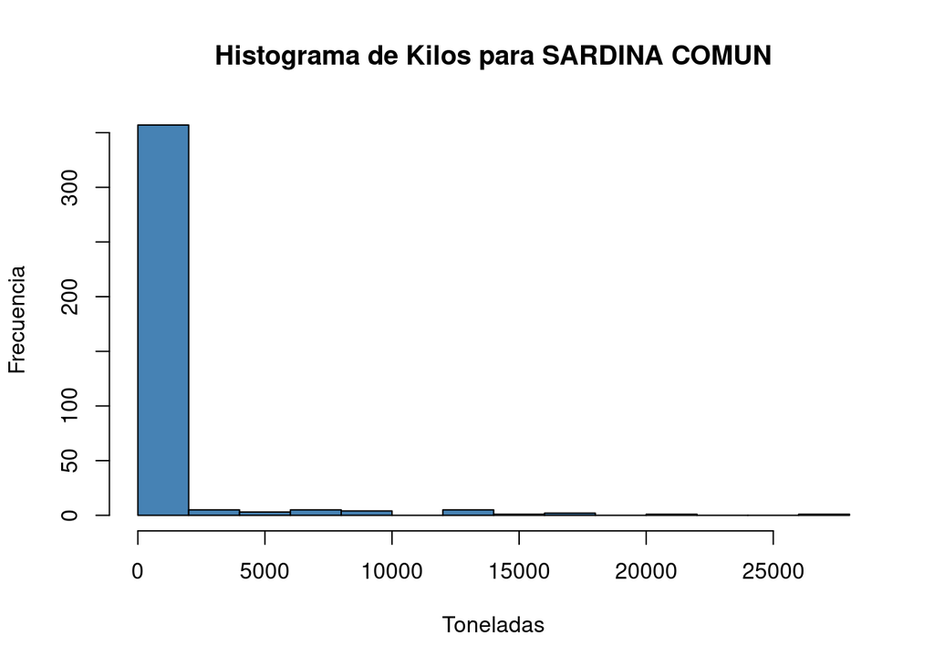

```r
hist(especie_sardina$Toneladas,col = "steelblue", xlab = "Toneladas", ylab = "Frecuencia",
     main = "Histograma de Kilos para SARDINA COMUN")
```

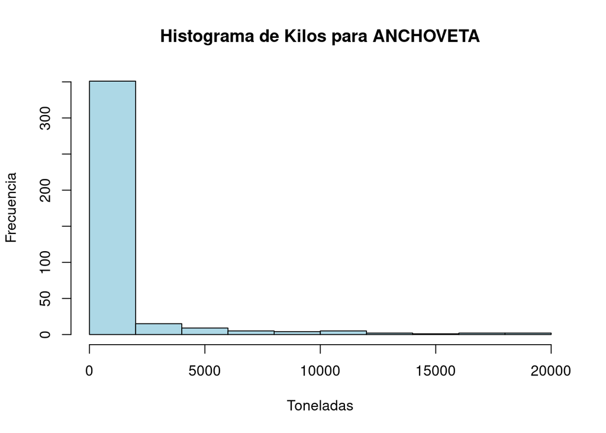

```r
hist(especie_anchoveta$Toneladas,col = "lightblue", xlab = "Toneladas", ylab = "Frecuencia",
     main = "Histograma de Kilos para ANCHOVETA")
```

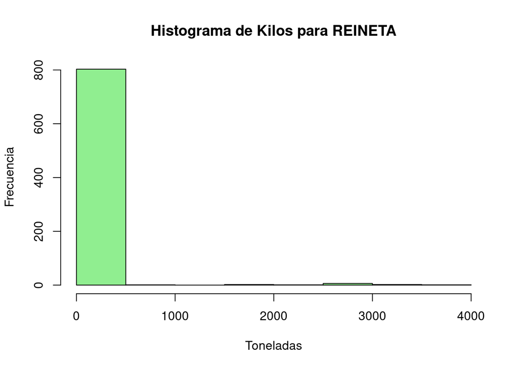

```r
hist(especie_reineta$Toneladas,col = "lightgreen", xlab = "Toneladas", ylab = "Frecuencia",
     main = "Histograma de Kilos para REINETA")
```

#### Veamos si los datos estan balanceados en una tabla de Frecuencia

```r
# Crear tabla de frecuencia para la variable Especie y Kilos
tabla_frecuencia <- table(RankingEspecies$Especie, RankingEspecies$Toneladas)

# Convertir la tabla de frecuencia en un dataframe
df_tabla_frecuencia <- as.data.frame.matrix(tabla_frecuencia)

# Agregar estadísticas a la tabla de frecuencia
df_tabla_frecuencia <- df_tabla_frecuencia %>%
  mutate(Suma = rowSums(.),
         Promedio = rowMeans(.),
         Desviacion = apply(., 1, sd))

# Imprimir la tabla de frecuencia utilizando kable
kable(df_tabla_frecuencia)
```

[output not shown]

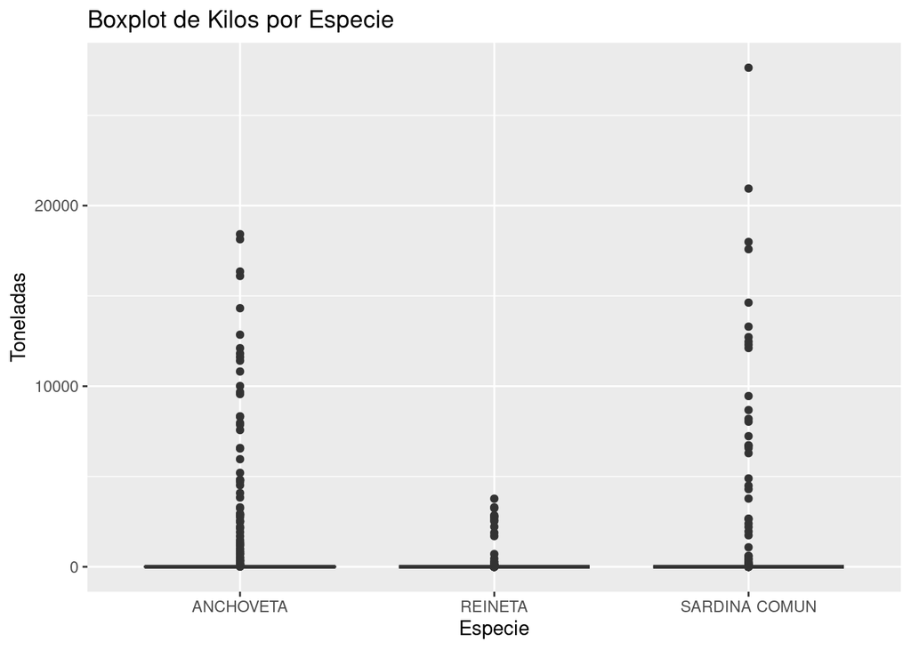

```r
ggplot(RankingEspecies, aes(x = Especie, y = Toneladas)) +
  geom_boxplot() +
  labs(x = "Especie", y = "Toneladas") +
  ggtitle("Boxplot de Kilos por Especie")
```